# Case Study #01 : Cyclistic Bike-Share

Created By : Harsh Choudhary

Last Updated : 21/02/2022

# **Prepare Phase**

### *Installing Packages and libraries*

```r
  install.packages("tidyverse")
  install.packages("lubridate")
  library(tidyverse)
  library(lubridate)
  library(readr)
```

### *Importing all Data Files from December-2020 to November-2021*

```r
td01 <- read_csv("C:/Users/Harsh/Desktop/Coursera/Google Data Analyst Certification/Case Study 1 - 1/202012-divvy-tripdata.csv")
td02 <- read_csv("C:/Users/Harsh/Desktop/Coursera/Google Data Analyst Certification/Case Study 1 - 1/202101-divvy-tripdata.csv")
td03 <- read_csv("C:/Users/Harsh/Desktop/Coursera/Google Data Analyst Certification/Case Study 1 - 1/202102-divvy-tripdata.csv")
td04 <- read_csv("C:/Users/Harsh/Desktop/Coursera/Google Data Analyst Certification/Case Study 1 - 1/202103-divvy-tripdata.csv")
td05 <- read_csv("C:/Users/Harsh/Desktop/Coursera/Google Data Analyst Certification/Case Study 1 - 1/202104-divvy-tripdata.csv")
td06 <- read_csv("C:/Users/Harsh/Desktop/Coursera/Google Data Analyst Certification/Case Study 1 - 1/202105-divvy-tripdata.csv")
td07 <- read_csv("C:/Users/Harsh/Desktop/Coursera/Google Data Analyst Certification/Case Study 1 - 1/202106-divvy-tripdata.csv")
td08 <- read_csv("C:/Users/Harsh/Desktop/Coursera/Google Data Analyst Certification/Case Study 1 - 1/202107-divvy-tripdata.csv")
td09 <- read_csv("C:/Users/Harsh/Desktop/Coursera/Google Data Analyst Certification/Case Study 1 - 1/202108-divvy-tripdata.csv")
td10 <- read_csv("C:/Users/Harsh/Desktop/Coursera/Google Data Analyst Certification/Case Study 1 - 1/202109-divvy-tripdata.csv")
td11 <- read_csv("C:/Users/Harsh/Desktop/Coursera/Google Data Analyst Certification/Case Study 1 - 1/202110-divvy-tripdata.csv")
td12 <- read_csv("C:/Users/Harsh/Desktop/Coursera/Google Data Analyst Certification/Case Study 1 - 1/202111-divvy-tripdata.csv")
```

### *Merging all dataset into single dataset.*

```r
complete_year <- rbind(td01,td02,td03,td04,td05,td06,td07,td08,td09,td10,td11,td12)
```

### *Inspecting data of Combined dataset.*

```r
View(complete_year)

head(complete_year)
```

```
## # A tibble: 6 x 13
##   ride_id rideable_type started_at          ended_at            start_station_n~
##   <chr>   <chr>         <dttm>              <dttm>              <chr>
## 1 70B6A9~ classic_bike  2020-12-27 12:44:29 2020-12-27 12:55:06 Aberdeen St & J~
## 2 158A46~ electric_bike 2020-12-18 17:37:15 2020-12-18 17:44:19 <NA>
## 3 526201~ electric_bike 2020-12-15 15:04:33 2020-12-15 15:11:28 <NA>
## 4 BE1196~ electric_bike 2020-12-15 15:54:18 2020-12-15 16:00:11 <NA>
## 5 69AF78~ electric_bike 2020-12-22 12:08:17 2020-12-22 12:10:59 <NA>
## 6 C1DECC~ electric_bike 2020-12-22 13:26:37 2020-12-22 13:34:50 <NA>
## # ... with 8 more variables: start_station_id <chr>, end_station_name <chr>,
## #   end_station_id <chr>, start_lat <dbl>, start_lng <dbl>, end_lat <dbl>,
## #   end_lng <dbl>, member_casual <chr>
```

```r
str(complete_year)
```

```
## spec_tbl_df [5,479,096 x 13] (S3: spec_tbl_df/tbl_df/tbl/data.frame)
##  $ ride_id           : chr [1:5479096] "70B6A9A437D4C30D" "158A465D4E74C54A" "5262016E0F1F2F9A" "BE119628E44F871E" ...
##  $ rideable_type     : chr [1:5479096] "classic_bike" "electric_bike" "electric_bike" "electric_bike" ...
##  $ started_at        : POSIXct[1:5479096], format: "2020-12-27 12:44:29" "2020-12-18 17:37:15" ...
##  $ ended_at          : POSIXct[1:5479096], format: "2020-12-27 12:55:06" "2020-12-18 17:44:19" ...
##  $ start_station_name: chr [1:5479096] "Aberdeen St & Jackson Blvd" NA NA NA ...
##  $ start_station_id  : chr [1:5479096] "13157" NA NA NA ...
##  $ end_station_name  : chr [1:5479096] "Desplaines St & Kinzie St" NA NA NA ...
##  $ end_station_id    : chr [1:5479096] "TA1306000003" NA NA NA ...
##  $ start_lat         : num [1:5479096] 41.9 41.9 41.9 41.9 41.8 ...
##  $ start_lng         : num [1:5479096] -87.7 -87.7 -87.7 -87.7 -87.6 ...
##  $ end_lat           : num [1:5479096] 41.9 41.9 41.9 41.9 41.8 ...
##  $ end_lng           : num [1:5479096] -87.6 -87.7 -87.7 -87.7 -87.6 ...
##  $ member_casual     : chr [1:5479096] "member" "member" "member" "member" ...
##  - attr(*, "spec")=
##   .. cols(
##   ..   ride_id = col_character(),
##   ..   rideable_type = col_character(),
##   ..   started_at = col_datetime(format = ""),
##   ..   ended_at = col_datetime(format = ""),
##   ..   start_station_name = col_character(),
##   ..   start_station_id = col_character(),
##   ..   end_station_name = col_character(),
##   ..   end_station_id = col_character(),
##   ..   start_lat = col_double(),
##   ..   start_lng = col_double(),
##   ..   end_lat = col_double(),
##   ..   end_lng = col_double(),
##   ..   member_casual = col_character()
##   .. )
##  - attr(*, "problems")=<externalptr>
```

```r
colnames(complete_year)
```

```
##  [1] "ride_id"            "rideable_type"      "started_at"
##  [4] "ended_at"           "start_station_name" "start_station_id"
##  [7] "end_station_name"   "end_station_id"     "start_lat"
## [10] "start_lng"          "end_lat"            "end_lng"
## [13] "member_casual"
```

# **Process Phase**

### *Adding new column, ride_length to calculate total time travelled*

```r
complete_year <- mutate(complete_year, ride_length = ended_at - started_at)
complete_year$ride_length <- as.numeric(as.character(complete_year$ride_length))
```

### *Removing the dataset which is not in use*

```r
rm(td01,td02,td03,td04,td05,td06,td07,td08,td09,td10,td11,td12)
```

### *Splitting/Extracting the date, month, day and year of each ride*

```r
complete_year$date <- as.Date(complete_year$started_at)
complete_year$month <- format(as.Date(complete_year$date), "%m")
complete_year$day <- format(as.Date(complete_year$date), "%d")
complete_year$year <- format(as.Date(complete_year$date), "%Y")
complete_year$day_of_week <- format(as.Date(complete_year$date), "%A")
```

### *Calculate total distance between the start and end point using euclidean method*

```r
complete_year$x <- (complete_year$end_lat-complete_year$start_lat)**2
complete_year$y <- (complete_year$end_lng-complete_year$start_lng)**2
complete_year$total_distance <- (complete_year$x + complete_year$y)**0.5
```

### *Inspecting the dataset*

```r
View(complete_year)

colnames(complete_year)
```

```
##  [1] "ride_id"            "rideable_type"      "started_at"
##  [4] "ended_at"           "start_station_name" "start_station_id"
##  [7] "end_station_name"   "end_station_id"     "start_lat"
## [10] "start_lng"          "end_lat"            "end_lng"
## [13] "member_casual"      "ride_length"        "date"
## [16] "month"              "day"                "year"
## [19] "day_of_week"        "x"                  "y"
## [22] "total_distance"
```

```r
summary(complete_year)
```

```
##    ride_id          rideable_type        started_at
##  Length:5479096     Length:5479096     Min.   :2020-12-01 00:01:15
##  Class :character   Class :character   1st Qu.:2021-05-31 17:13:15
##  Mode  :character   Mode  :character   Median :2021-07-25 12:16:02
##                                        Mean   :2021-07-17 15:43:28
##                                        3rd Qu.:2021-09-15 16:30:21
##                                        Max.   :2021-11-30 23:59:56
##
##     ended_at                   start_station_name start_station_id
##  Min.   :2020-11-25 07:40:56   Length:5479096     Length:5479096
##  1st Qu.:2021-05-31 17:45:37   Class :character   Class :character
##  Median :2021-07-25 12:42:07   Mode  :character   Mode  :character
##  Mean   :2021-07-17 16:03:38
##  3rd Qu.:2021-09-15 16:48:19
##  Max.   :2021-12-02 06:41:33
##
##  end_station_name   end_station_id       start_lat       start_lng
##  Length:5479096     Length:5479096     Min.   :41.64   Min.   :-87.84
##  Class :character   Class :character   1st Qu.:41.88   1st Qu.:-87.66
##  Mode  :character   Mode  :character   Median :41.90   Median :-87.64
##                                        Mean   :41.90   Mean   :-87.65
##                                        3rd Qu.:41.93   3rd Qu.:-87.63
##                                        Max.   :42.07   Max.   :-87.52
##
##     end_lat         end_lng       member_casual       ride_length
##  Min.   :41.39   Min.   :-88.97   Length:5479096     Min.   :-1742998
##  1st Qu.:41.88   1st Qu.:-87.66   Class :character   1st Qu.:     410
##  Median :41.90   Median :-87.64   Mode  :character   Median :     728
##  Mean   :41.90   Mean   :-87.65                      Mean   :    1209
##  3rd Qu.:41.93   3rd Qu.:-87.63                      3rd Qu.:    1320
##  Max.   :42.17   Max.   :-87.49                      Max.   : 3356649
##  NA's   :4738    NA's   :4738
##       date               month               day                year
##  Min.   :2020-12-01   Length:5479096     Length:5479096     Length:5479096
##  1st Qu.:2021-05-31   Class :character   Class :character   Class :character
##  Median :2021-07-25   Mode  :character   Mode  :character   Mode  :character
##  Mean   :2021-07-17
##  3rd Qu.:2021-09-15
##  Max.   :2021-11-30
##
##  day_of_week              x               y         total_distance
##  Length:5479096     Min.   :0.000   Min.   :0.000   Min.   :0.000
##  Class :character   1st Qu.:0.000   1st Qu.:0.000   1st Qu.:0.010
##  Mode  :character   Median :0.000   Median :0.000   Median :0.017
##                     Mean   :0.000   Mean   :0.000   Mean   :0.022
##                     3rd Qu.:0.000   3rd Qu.:0.000   3rd Qu.:0.030
##                     Max.   :0.281   Max.   :1.392   Max.   :1.294
##                     NA's   :4738    NA's   :4738    NA's   :4738
```

### *Sorting dataset in an ascending order by date.*

```r
complete_year %>% arrange(started_at)
```

```
## # A tibble: 5,479,096 x 22
##    ride_id          rideable_type started_at          ended_at
##    <chr>            <chr>         <dttm>              <dttm>
##  1 1C46BF5EB60CC524 electric_bike 2020-12-01 00:01:15 2020-12-01 00:06:53
##  2 1405BFC02FDB5190 electric_bike 2020-12-01 00:01:27 2020-12-01 00:06:33
##  3 892ECFAB44203EAD docked_bike   2020-12-01 00:07:08 2020-12-01 00:10:02
##  4 7F0119D219127E62 docked_bike   2020-12-01 00:11:37 2020-12-01 00:21:31
##  5 F5C7D6CF285DD638 docked_bike   2020-12-01 00:21:28 2020-12-01 00:28:04
##  6 0D424379FB10DC7A electric_bike 2020-12-01 00:21:32 2020-12-01 00:26:27
##  7 1D2B177267724C28 electric_bike 2020-12-01 00:25:40 2020-12-01 00:36:35
##  8 A7822D35BE4F81C1 electric_bike 2020-12-01 00:25:53 2020-12-01 00:28:28
##  9 641F2635C5E7BA04 electric_bike 2020-12-01 00:26:29 2020-12-01 00:37:22
## 10 DC7DC1F9434292F5 docked_bike   2020-12-01 00:27:36 2020-12-01 00:30:07
## # ... with 5,479,086 more rows, and 18 more variables:
## #   start_station_name <chr>, start_station_id <chr>, end_station_name <chr>,
## #   end_station_id <chr>, start_lat <dbl>, start_lng <dbl>, end_lat <dbl>,
## #   end_lng <dbl>, member_casual <chr>, ride_length <dbl>, date <date>,
## #   month <chr>, day <chr>, year <chr>, day_of_week <chr>, x <dbl>, y <dbl>,
## #   total_distance <dbl>
```

### *Droping all rows with any NULL values.*

```r
cleaned_df <- complete_year %>% drop_na()
```

### *Removing Duplicate data.*

```r
unique_df <- distinct(cleaned_df)
```

### *Inspecting the dataset*

```r
View(unique_df)

colnames(unique_df)
```

```
##  [1] "ride_id"            "rideable_type"      "started_at"
##  [4] "ended_at"           "start_station_name" "start_station_id"
##  [7] "end_station_name"   "end_station_id"     "start_lat"
## [10] "start_lng"          "end_lat"            "end_lng"
## [13] "member_casual"      "ride_length"        "date"
## [16] "month"              "day"                "year"
## [19] "day_of_week"        "x"                  "y"
## [22] "total_distance"
```

```r
summary(unique_df)
```

```
##    ride_id          rideable_type        started_at
##  Length:4525842     Length:4525842     Min.   :2020-12-01 00:07:08
##  Class :character   Class :character   1st Qu.:2021-05-28 09:26:32
##  Mode  :character   Mode  :character   Median :2021-07-22 13:44:09
##                                        Mean   :2021-07-14 02:56:52
##                                        3rd Qu.:2021-09-11 11:42:54
##                                        Max.   :2021-11-30 23:59:56
##     ended_at                   start_station_name start_station_id
##  Min.   :2020-11-25 07:40:56   Length:4525842     Length:4525842
##  1st Qu.:2021-05-28 09:44:32   Class :character   Class :character
##  Median :2021-07-22 14:09:30   Mode  :character   Mode  :character
##  Mean   :2021-07-14 03:16:50
##  3rd Qu.:2021-09-11 12:04:45
##  Max.   :2021-12-01 00:15:03
##  end_station_name   end_station_id       start_lat       start_lng
##  Length:4525842     Length:4525842     Min.   :41.65   Min.   :-87.83
##  Class :character   Class :character   1st Qu.:41.88   1st Qu.:-87.66
##  Mode  :character   Mode  :character   Median :41.90   Median :-87.64
##                                        Mean   :41.90   Mean   :-87.64
##                                        3rd Qu.:41.93   3rd Qu.:-87.63
##                                        Max.   :42.06   Max.   :-87.53
##     end_lat         end_lng       member_casual       ride_length
##  Min.   :41.65   Min.   :-87.83   Length:4525842     Min.   :-1742998
##  1st Qu.:41.88   1st Qu.:-87.66   Class :character   1st Qu.:     421
##  Median :41.90   Median :-87.64   Mode  :character   Median :     739
##  Mean   :41.90   Mean   :-87.64                      Mean   :    1198
##  3rd Qu.:41.93   3rd Qu.:-87.63                      3rd Qu.:    1338
##  Max.   :42.17   Max.   :-87.52                      Max.   : 3356649
##       date               month               day                year
##  Min.   :2020-12-01   Length:4525842     Length:4525842     Length:4525842
##  1st Qu.:2021-05-28   Class :character   Class :character   Class :character
##  Median :2021-07-22   Mode  :character   Mode  :character   Mode  :character
##  Mean   :2021-07-13
##  3rd Qu.:2021-09-11
##  Max.   :2021-11-30
##  day_of_week              x                   y             total_distance
##  Length:4525842     Min.   :0.000e+00   Min.   :0.000e+00   Min.   :0.000000
##  Class :character   1st Qu.:1.256e-05   1st Qu.:1.153e-05   1st Qu.:0.009388
##  Mode  :character   Median :9.189e-05   Median :8.577e-05   Median :0.016768
##                     Mean   :4.737e-04   Mean   :3.282e-04   Mean   :0.021569
##                     3rd Qu.:3.845e-04   3rd Qu.:3.203e-04   3rd Qu.:0.028688
##                     Max.   :9.215e-02   Max.   :3.536e-02   Max.   :0.304295
```

# **Analyse Phase**

### *Calculating the mean and max ride-duration in minutes for both type of riders.*

```r
mean_and_max <- unique_df %>%
  group_by(member_casual) %>%
  summarise(Mean_ride_len_inMinutes=(mean(ride_length)/60), Max_ride_len_inMinutes=(max(ride_length))/60)
View(mean_and_max)
```

### *Calculating the total rides for both type of riders by weekday by counting ride_id.*

```r
Number_of_rides <- unique_df %>%
  mutate(weekday = wday(started_at, label = TRUE)) %>%
  group_by(member_casual, weekday) %>%
  summarise(total_rides = n(), average_duration_in_minutes = abs((mean(ride_length))/60)) %>%
  arrange(member_casual, weekday)
View(Number_of_rides)
```

### **Findings $01 :** *Maximum number of rides for Casual was in Saturday and for Member was in Wednesday*

```r
Number_of_rides %>% summarise(max_rides = max(total_rides))
```

```
## # A tibble: 2 x 2
##   member_casual max_rides
##   <chr>             <int>
## 1 casual           464628
## 2 member           387971
```

### **Findings $02 :** *Minimum number of rides for Casual was in Tuesday and for Member was in Sunday*

```r
Number_of_rides %>% summarise(min_rides = min(total_rides))
```

```
## # A tibble: 2 x 2
##   member_casual min_rides
##   <chr>             <int>
## 1 casual           214254
## 2 member           310503
```

### *Graph for Weekday vs Total Rides*

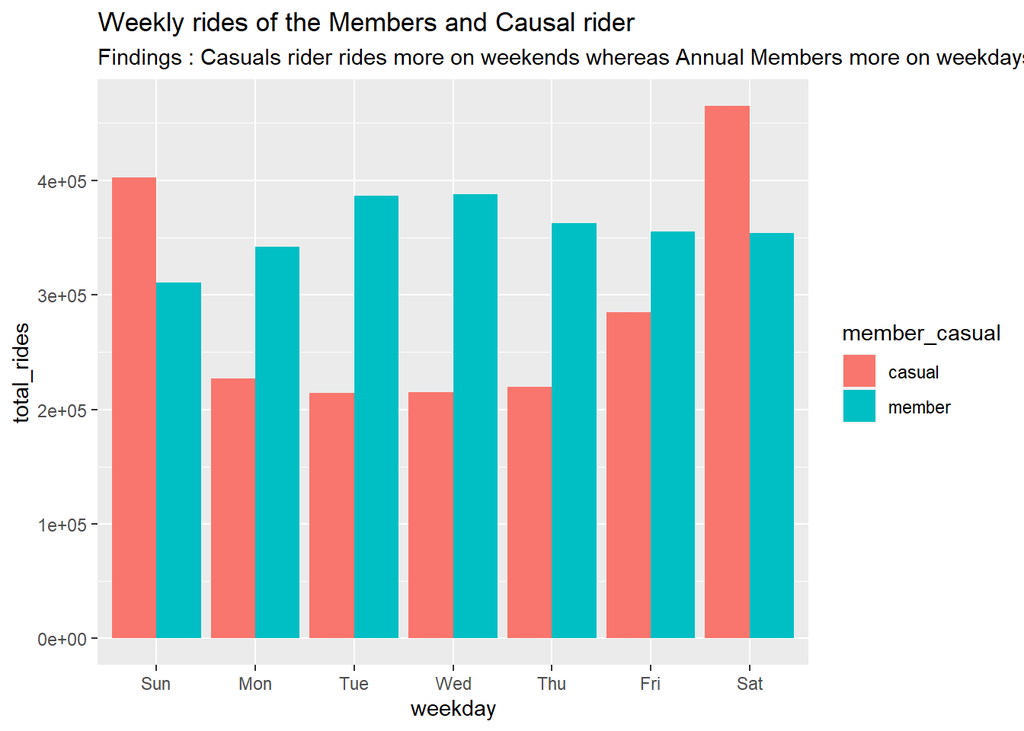

```r
ggplot(data=Number_of_rides) +
  geom_col(mapping= aes(x = weekday, y = total_rides, fill = member_casual), position = "dodge") +
  labs(title = "Weekly rides of the Members and Causal rider",
       subtitle = "Findings : Casuals rider rides more on weekends whereas Annual Members more on weekdays.")
```

**Findings $03 :** *Casuals rider rides more on weekends whereas Annual Members more on weekdays.*

### *Graph for Weekday vs Average Ride Duration*

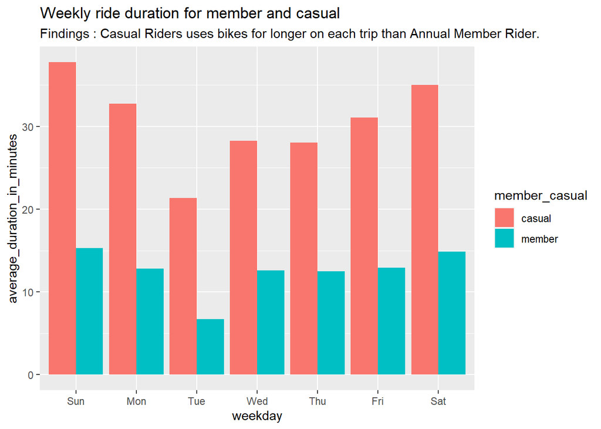

```r
ggplot(data=Number_of_rides) +
  geom_col(mapping= aes(x = weekday, y = average_duration_in_minutes, fill = member_casual), position = "dodge") +
  labs(title = "Weekly ride duration for member and casual",
       subtitle = "Findings : Casual Riders uses bikes for longer on each trip than Annual Member Rider.")
```

### *Extracting Important features of large dataset into new dataset*

```r
final_df <- unique_df %>%
  select(ride_id, rideable_type, ride_length, member_casual, total_distance, day_of_week, month, year)
summary(final_df)
```

```
##    ride_id          rideable_type       ride_length       member_casual
##  Length:4525842     Length:4525842     Min.   :-1742998   Length:4525842
##  Class :character   Class :character   1st Qu.:     421   Class :character
##  Mode  :character   Mode  :character   Median :     739   Mode  :character
##                                        Mean   :    1198
##                                        3rd Qu.:    1338
##                                        Max.   : 3356649
##  total_distance     day_of_week           month               year
##  Min.   :0.000000   Length:4525842     Length:4525842     Length:4525842
##  1st Qu.:0.009388   Class :character   Class :character   Class :character
##  Median :0.016768   Mode  :character   Mode  :character   Mode  :character
##  Mean   :0.021569
##  3rd Qu.:0.028688
##  Max.   :0.304295
```

```r
View(final_df)
```

# **Share Phase**

### *Calculating total rides for both type of riders for each month by counting ride_id.*

```r
Number_of_rides_by_month <- final_df %>%
  group_by(member_casual, month) %>%
  summarise(total_rides = n()) %>%
  arrange(member_casual, month)
View(Number_of_rides_by_month)
```

### *Graph for both member’s total rides in each month.*

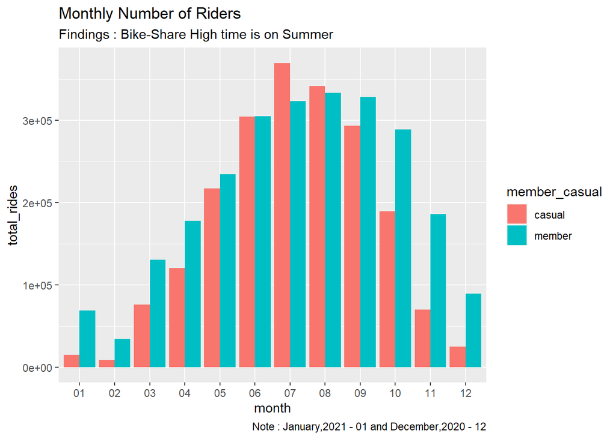

```r
ggplot(data=Number_of_rides_by_month) +
  geom_col(mapping= aes(x = month, y = total_rides, fill = member_casual), position = "dodge") +
  #facet_wrap(~member_casual) +
  labs(title ="Monthly Number of Riders", subtitle = "Findings : Bike-Share High time is on Summer", caption = "Note : January,2021 - 01 and December,2020 - 12")
```

**Findings $05 :** *Both the riders are increasing during the month of May-September i.e during Summer and decreases during Winter.*

### *Bikes not returned in 24 hours.*

```r
bike_not_return <- final_df %>%
  group_by(member_casual, day_of_week) %>%
  filter(ride_length>86400)%>%
  summarise(total_rides = n())
View(bike_not_return)
```

### *Graph for Bikes Not Returned in a Day.*

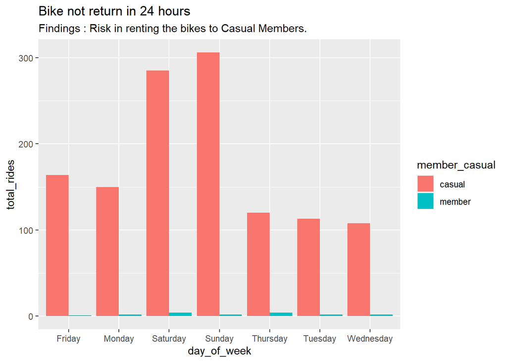

```r
ggplot(data=bike_not_return) +
  geom_col(mapping= aes(x = day_of_week, y = total_rides, fill = member_casual), position = "dodge") +
  labs(title ="Bike not return in 24 hours",
       subtitle = "Findings : Risk in renting the bikes to Casual Members.")
```

**Findings $06 :** *Annual Member tend to take far better care of our bikes are much more careful about returning the bike to a docking station in time than a typical casual rider, even though they use them far more often.*

#### *Checking the total rides for Annual Member for docked_bike.*

```r
total_docked_bike <- cleaned_df %>%
  filter(rideable_type=="docked_bike" , member_casual=="member") %>%
  summarise(total_rides = n())
View(total_docked_bike)
```

### *Checking the rider preference for bikes.*

```r
preferenced_bike <- final_df %>%
  group_by(member_casual, rideable_type) %>%
  summarise(total_rides = n()) %>%
  arrange(member_casual, rideable_type)
View(preferenced_bike)
```

### *Graph for both Member’s preference bike*

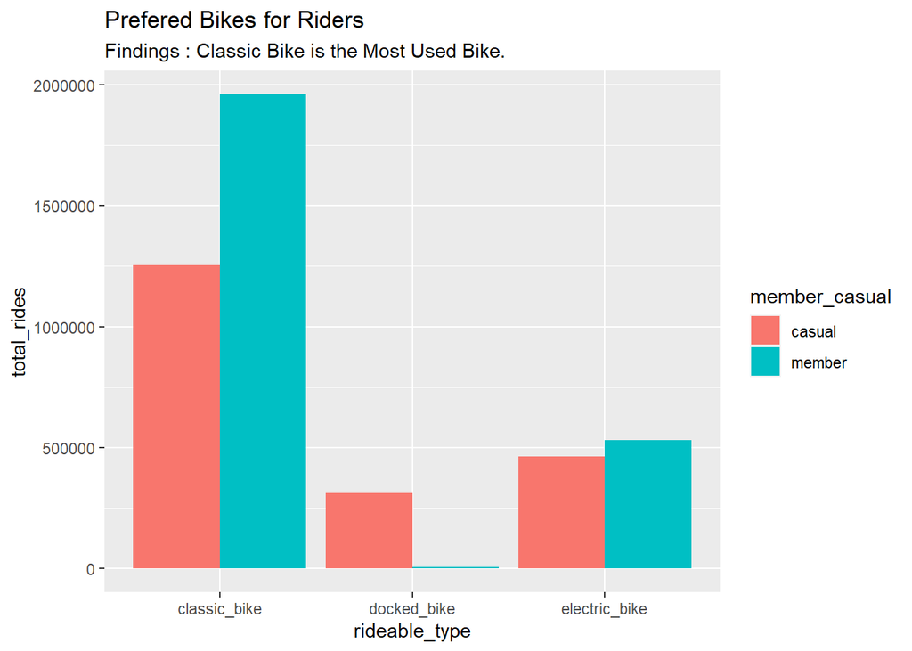

```r
ggplot(data=preferenced_bike) +
  geom_col(mapping= aes(x = rideable_type, y = total_rides, fill = member_casual), position = "dodge")+
  labs(title ="Prefered Bikes for Riders",
       subtitle = "Findings : Classic Bike is the Most Used Bike.")
```

**Findings $07 :** *Classic bike are the most popular bike compare to other 2 bikes for both the riders, the preference for bikes are classic, electric and then docked bike.*